# HW3 Report

Alim Bugra Cinar

16 November 2018

# 1. Introduction

This is my homework report for Homework 3 of IE 582 Statistical Learning for Data Mining class at Bogazici University Industrial Engineering Department. In this project we are given two tasks. In the first task, we are given uWaveGestureLibrary, which is a three-axis accelerometer data collected to characterize eight gesture patterns. Our task is to firstly visualize the gestures and secondly apply nearest-neighbor classifier to classify the test data. In the second task, we will use a penalized regression approach with fused penalties to classify EcG data.

# 2. Task 1

## 2.1 Data Loading and Preprocessing

In this part, I will firstly load the required libraries and data. Then, as we are asked to plot the gestures, I will create a function for this task. The data consists of acceleration information, therefore, we need to convert it to position information first. Then, we need to plot that positions. The function does this task.

## 2.2 Task 1.a

In this part, I will plot 8 gestures. The blue triangles show where the movement begins, and the red crosses show where the movement ends.

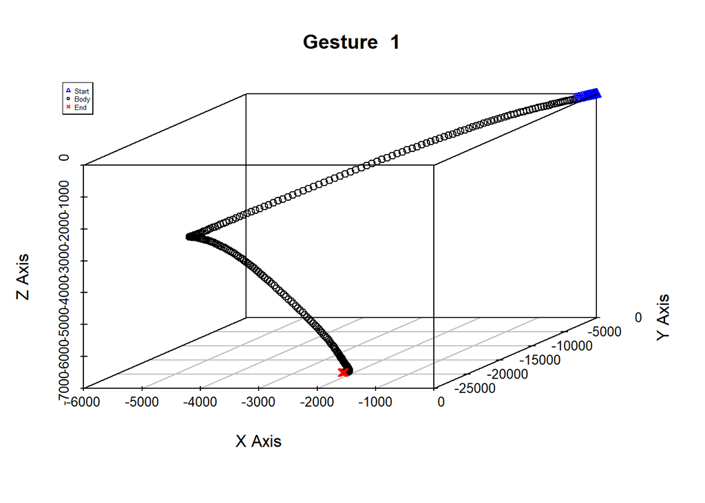

```r
pathplotter(11)
```

The plot above shows the first Gesture. When it is compared to original gesture 1, it looks mirrored against Y Axis.

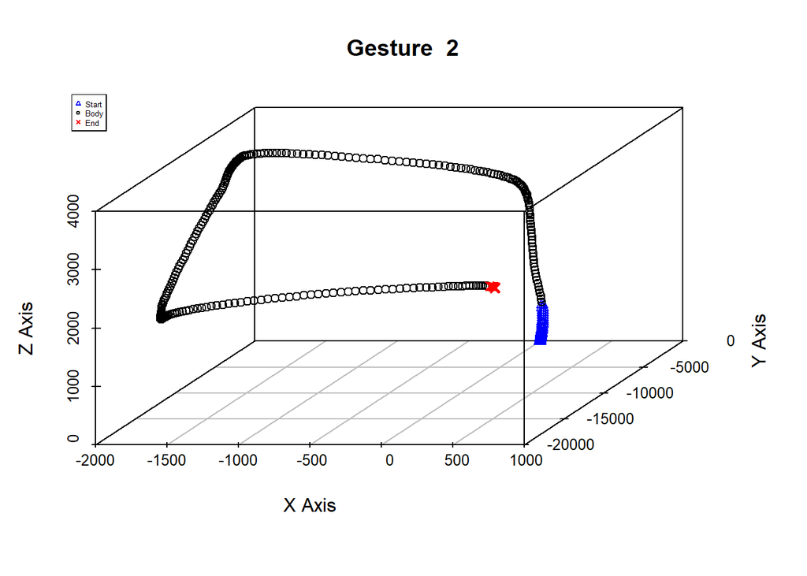

```r
pathplotter(20)
```

The plot above shows the second gesture. It is mirrored against Y Axis like the first gesture.

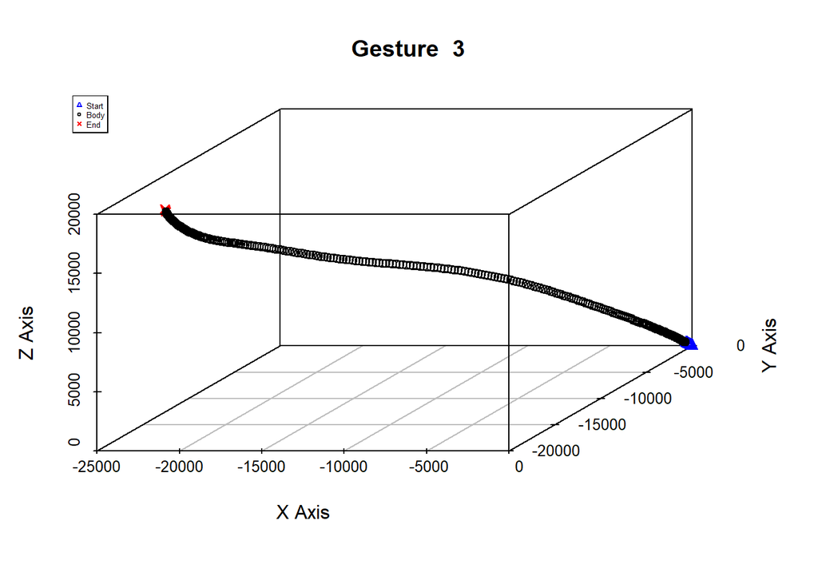

```r
pathplotter(13)
```

The plot above shows the 3rd gesture, and the mirroring problem continues here as well.

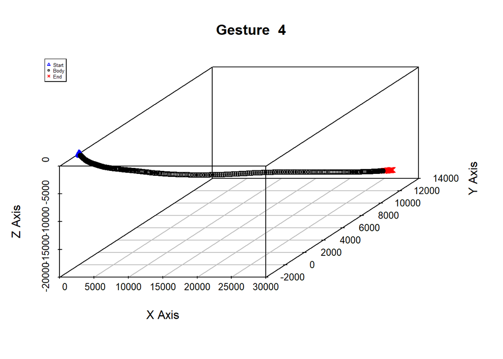

```r
pathplotter(5)
```

Same issue can be observed in the 4th Gesture’s plot.

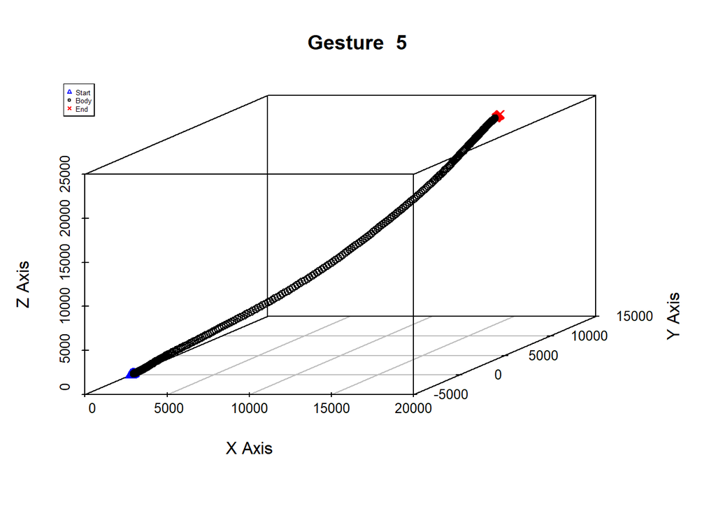

```r
pathplotter(3)
```

5th gesture is plotted above. This time the mirroring problem didn’t occur, however, the direction of the gesture is not exactly vertical. It is distorted in the direction of x=y line (in positive direction). Movement in Z Axis is as expected.

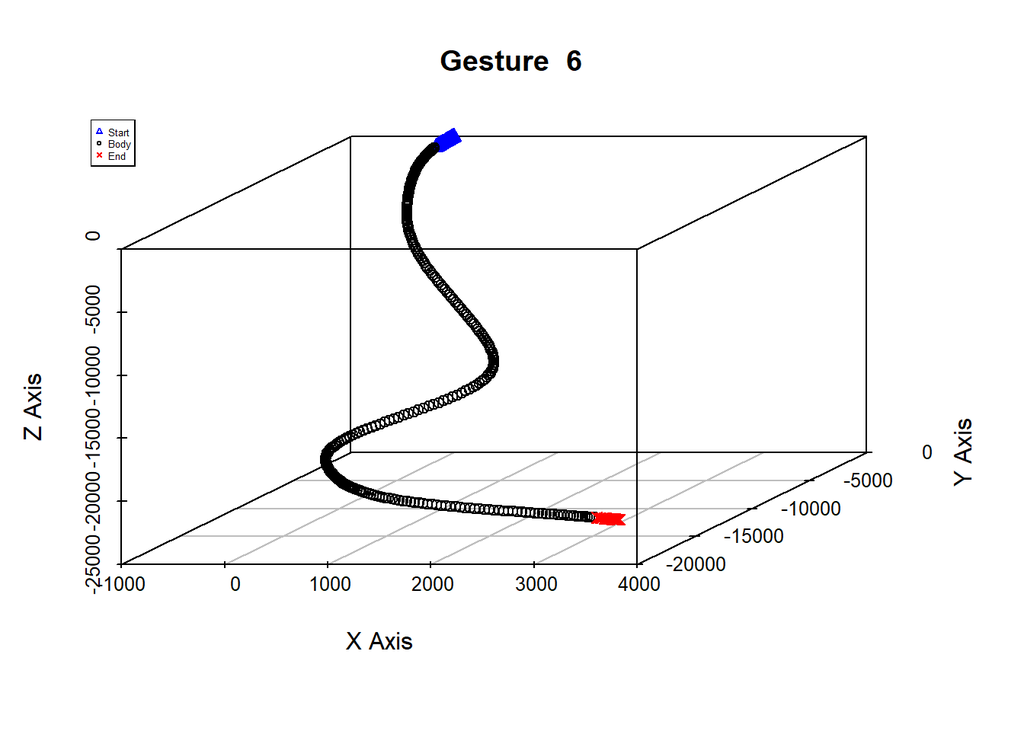

```r
pathplotter(1)
```

The figure above shows the 6th gesture. The movement in the Z Axis is as expected, however, the change in the X and Y axes made the movement S-shaped.

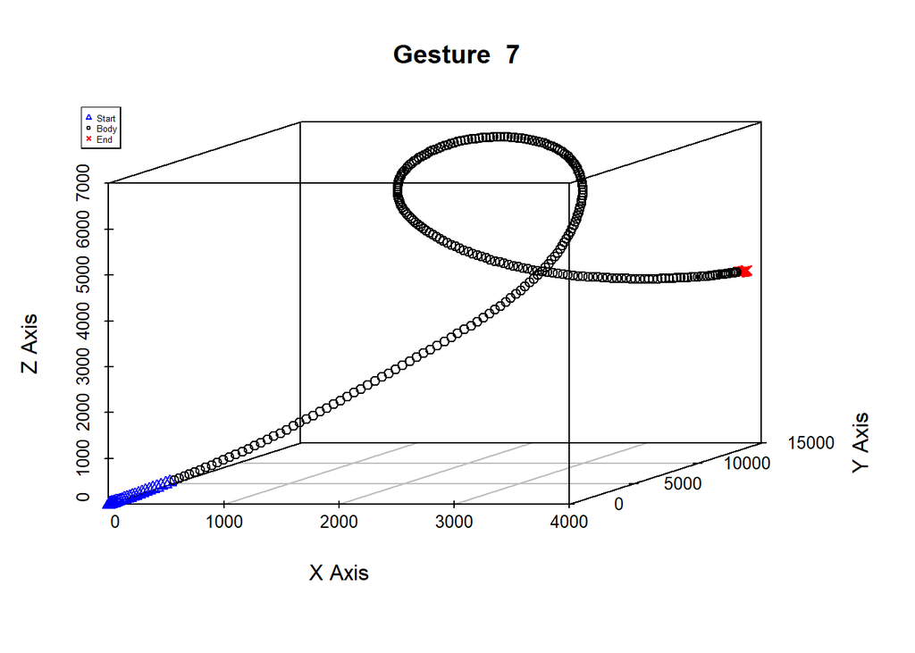

```r
pathplotter(7)
```

7th gesture is plotted above. This time the circler movement is as expected, however, the shape is mirrored against Y Axis.

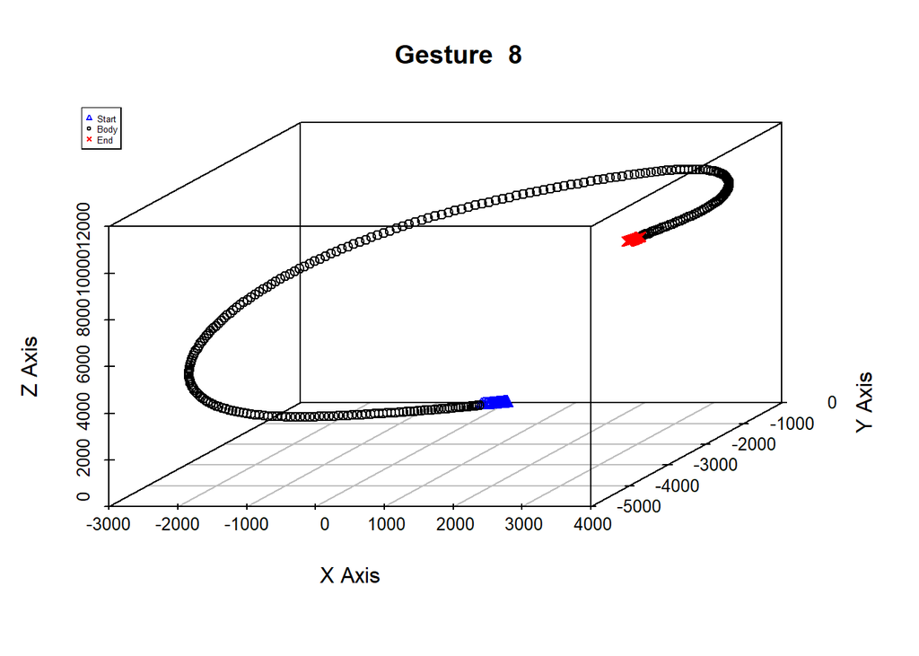

```r
pathplotter(6)
```

Finally, I plotted the 8th gesture. The gesture is circler as expected. However, the mirroring problem continues here as well. We can try solve the problem by mirroring the images against Y axis. The correcting function and sample plots for the first two gestures are shown below.

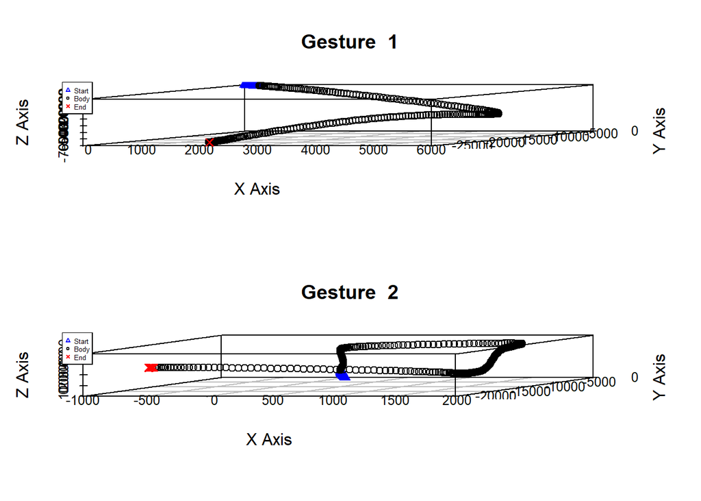

```r
par(mfrow = c(2,1))
pathplotter2(11)
pathplotter2(20)
```

## 2.3 Task 1.b

In this task, I will train 2 NN models, which are using Euclidean and Manhattan distances. Firstly, I will do scale the data, then I will find the optimal k values by using 10-fold cross validation for both of the models.

I will use knn function from FNN package in the first part as it uses euclidean distances, and in the second part I will use nn2 function from RANN.L1 package as it uses manhattan distances.

```r
comparison <- cvresult[,list(Accu=mean(Predictions==Real)),by=list(Method,Klev)]
comparison <- comparison[order(Accu)]
comparison
```

```
##     Method Klev      Accu
##  1:    knn   10 0.9302455
##  2:    knn    9 0.9320312
##  3:    knn    8 0.9327009
##  4:    knn    7 0.9367188
##  5:    knn    2 0.9379464
##  6:    knn    6 0.9385045
##  7:    knn    5 0.9422991
##  8:    knn    1 0.9429688
##  9:    knn    4 0.9460937
## 10:    knn    3 0.9474330
```

As we can see from the results above, Model using Euclidean Distance best performs with k = 3, with an accuracy of 94.7%.

```r
comparison <- cvresult[,list(Accu=mean(Predictions==Real)),by=list(Method,Klev)]
comparison <- comparison[order(Accu)]
comparison
```

```
##     Method Klev      Accu
##  1:    knn   10 0.9044531
##  2:    knn    9 0.9090898
##  3:    knn    8 0.9139090
##  4:    knn    7 0.9185906
##  5:    knn    6 0.9247954
##  6:    knn    5 0.9302679
##  7:    knn    4 0.9348772
##  8:    knn    3 0.9399926
##  9:    knn    2 0.9441406
## 10:    knn    1 0.9578125
```

As it is shown in the table above, the manhattan distance model best performs with k = 1, with an accuracy of 95.8%.

## 2.4 Task 1.c

In this part, I will do evaluate the performance of the models on test data. I will present them in confusion matrices. At last, I will present the runtime records as an additional information.

```r
euc_comp <- (Predictions==testclass)
table(Predictions,testclass)
```

```
##            testclass
## Predictions   1   2   3   4   5   6   7   8
##           1 430   1   2   6   3   8   1   0
##           2   0 449   0   0   0   0   0   0
##           3   0   0 414   0   7   5   2   0
##           4   3   0   0 372   1  17   0   1
##           5   0   0  13  59 420  27   0   1
##           6   4   0  21   7   2 391   0   0
##           7   0   2   4   0   0   1 444   0
##           8   0   0   0   6   0   0   0 458
```

```r
accuracy <- sum(euc_comp)/length(testclass)
accuracy
```

```
## [1] 0.9430486
```

As we can see, the euclidean model works with 94.3% accuracy which is a very high value. The accuracy is also very close to the predicted accuracy in cross validation.

```r
table(Predictions,testclass)
```

```
##            testclass
## Predictions   1   2   3   4   5   6   7   8
##           1 433   1   2   4   3   6   0   0
##           2   0 451   0   0   0   0   0   0
##           3   0   0 415   0   9   6   3   0
##           4   1   0   0 397   4  11   0   3
##           5   0   0  16  38 414  17   0   1
##           6   3   0  16   8   3 409   0   0
##           7   0   0   5   0   0   0 444   0
##           8   0   0   0   3   0   0   0 456
```

```r
accuracy <- sum(man_comp)/length(testclass)
accuracy
```

```
## [1] 0.9544947
```

The manhattan model’s accuracy is even better than the first one. The value is 95.4%, which is very close to the result in cross validation.

```r
times <- rbind(cv_euc_time,cv_manh_time,euc_pred_time,manh_pred_time)
times[,1:3]
```

```
##                user.self sys.self elapsed
## cv_euc_time       152.86     3.99  173.53
## cv_manh_time      130.61    10.00  146.76
## euc_pred_time       3.27     0.01    3.29
## manh_pred_time      3.45     0.03    3.48
```

The table above shows the runtimes of different parts within Task 1. First row is cross validation time of Euclidean Model, second is cross Validation time of Manhattan Model, third is Prediction time of Euclidean model and the last one is Prediction time of Manhattan model.

# 3. Task 2

In this task, we are asked to create a logistic regression model using fused lasso penalties. In this part, I will firstly load and preprocess the data, then train the model. In the second part of the task, we will manipulate the data and train another model on the new data.

## 3.1 Task 2.a

Now, I will firstly determine the optimal values of the parameters of ridge and fused lasso penalties by using 10-fold cross validation. Then, I will train my model by using the optimal parameter values.

```r
sum(pred_trainclass==trainclass)
```

```
## [1] 96
```

```r
table(trainclass, pred_trainclass )
```

```
##           pred_trainclass
## trainclass  0  1
##          0 30  1
##          1  3 66
```

Results for training data. Prediction accuracy of the model with training data is 96%, which is a very high accuracy.

```r
sum(pred_testclass == testclass)
```

```
## [1] 88
```

```r
table(testclass, pred_testclass)
```

```
##          pred_testclass
## testclass  0  1
##         0 30  6
##         1  6 58
```

We can see the accuracy and confusion matrix of the model for the test data. Accuracy is 88%, which is very high. Even tough the accuracy on the training data is 96%, we can see that the model does not overfits, as the test result are very high as well. Both classes has same number of wrong guesses.

## 3.2 Task 2.b

```r
fused_model
```

```
## Penalized logistic regression object
## 97 regression coefficients of which 38 are non-zero
##
## Loglikelihood =   -23.40259
## L1 penalty =  8.964054   at lambda1 =  2.129277
## L2 penalty =  2.339566   at lambda2 =  1.027367
```

[figure not shown]

```r
c <- coefficients(fused_model, "all")
plot(traindata[1,], type = "l", col = "red", ylim = c(min(traindata[1,], traindata[2,], c), max(traindata[1,], traindata[2,], c)), xlab = "Time", ylab = "Values", main = "ECG Data & Coefficients, Original Model")
points(traindata[2,], type = "l", col = "blue")
points(c, type = "l", col = "green")
legend("bottomleft", cex = 0.3, legend = c("Class 0", "Class 1", "Coefficients"), col = c("red", "blue", "green"), pch = 1)
```

As we can see in the figure above, the regression coefficients correspond to huge changes in the movements of ECG plots. Where the plots are somehow more stabile, the coefficient are zero or very close to zero. In the areas where the movements are higher, the values of the coefficients respond them. Also there are 38 nonzero coefficients in the model, and the optimal lambda values are 2.13 & 1.03.

## 3.3 Task 2.c

In this part, I will firstly calculate the new datasets, then find optimal parameters of the penalties. Finally, I will train the model and present the results.

```r
sum(pred_trainclass_c == trainclass_c)
```

```
## [1] 90
```

```r
table(trainclass_c,pred_trainclass_c)
```

```
##             pred_trainclass_c
## trainclass_c  0  1
##            0 24  7
##            1  3 66
```

```r
sum(pred_testclass_c == testclass_c)
```

```
## [1] 86
```

```r
table(testclass_c, pred_testclass_c)
```

```
##            pred_testclass_c
## testclass_c  0  1
##           0 27  9
##           1  5 59
```

The results for the test data are shown above. The performance of the model on test data is 86%, which is not as high as the original models’ performance (88%). However, while original model has a 8% difference between training and test performance, this model has 4% difference. The similar performances on the training and test data may be interpreted as the latter model is more robust, and behaves as expected. Additinally, false negative and false positive number distribution is also like the result on the training data.

## 3.4 Task 2.d

```r
fused_model_c
```

```
## Penalized logistic regression object
## 97 regression coefficients of which 18 are non-zero
##
## Loglikelihood =   -34.04762
## L1 penalty =  7.372863   at lambda1 =  1.035307
## L2 penalty =  7.239823   at lambda2 =  2.218847
```

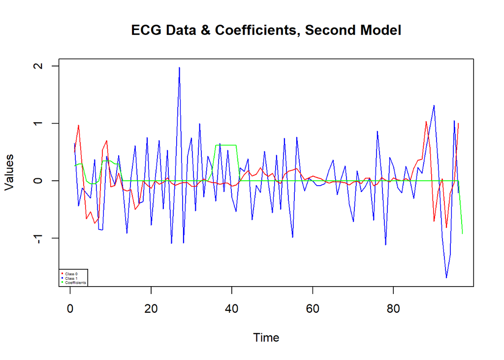

```r
c2 <- coefficients(fused_model_c,"all")
plot(traindata_c[2,], type = "l", col = "blue", ylim = c(min(traindata_c[1,], traindata_c[2,], c2), max(traindata_c[1,], traindata_c[2,], c2)), xlab = "Time", ylab = "Values", main = "ECG Data & Coefficients, Second Model")
points(testdata_c[5,], type = "l", col = "red")
points(c2, type = "l", col = "green")
legend("bottomleft", cex = 0.3, legend = c("Class 0", "Class 1", "Coefficients"), col = c("red", "blue", "green"), pch = 1)
```

When we look at the graph we can see nonzero coefficients are collected around close indexes. However, the second model has less nonzero elements then the first one. The nonzero elements are also larger in the second model. The number of nonzeroes are 18, and lambdas are 1.04 & 2.22. The plot below shows both of the plots for comparison.

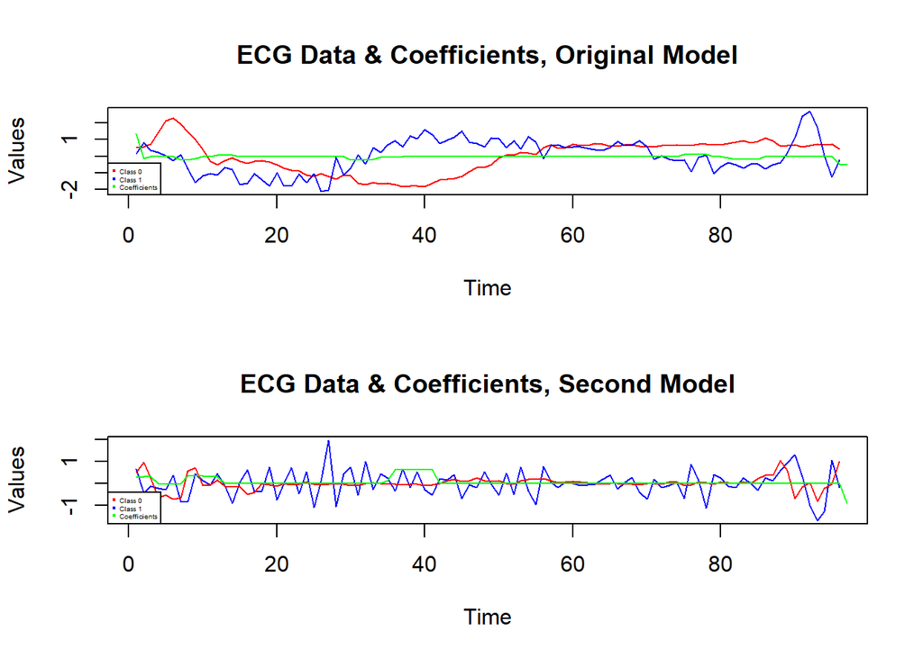

```r
par(mfrow = c(2,1))
plot(traindata[1,], type = "l", col = "red", ylim = c(min(traindata[1,], traindata[2,], c), max(traindata[1,], traindata[2,], c)), xlab = "Time", ylab = "Values", main = "ECG Data & Coefficients, Original Model")
points(traindata[2,], type = "l", col = "blue")
points(c, type = "l", col = "green")
legend("bottomleft", cex = 0.3, legend = c("Class 0", "Class 1", "Coefficients"), col = c("red", "blue", "green"), pch = 1)
plot(traindata_c[2,], type = "l", col = "blue", ylim = c(min(traindata_c[1,], traindata_c[2,], c2), max(traindata_c[1,], traindata_c[2,], c2)), xlab = "Time", ylab = "Values", main = "ECG Data & Coefficients, Second Model")
points(testdata_c[5,], type = "l", col = "red")
points(c2, type = "l", col = "green")
legend("bottomleft", cex = 0.3, legend = c("Class 0", "Class 1", "Coefficients"), col = c("red", "blue", "green"), pch = 1)
```